# Introduction

This is a supporting document for an example application of the a Management Strategy Evaluation (MSE) analysis to the Antarctic Krill fishery. The main goal of the analysis is to show the value of the `openMSE` simulation tool in assessing and developing alternative sustainable management strategies that are robust under data-moderate conditions such as the krill fishery.

This document provides a description of the input parameter values defining a base-case Operating Model (OM) for the Krill fishery, specifically whithin FAO’s Statistical Area 48. Many of the input values, particularly those related to Stock and Fleet parameters, were extracted from the ensemble analysis presented in D. Maschette et al. (2021). The analysis by D. Maschette et al. (2021) employed an implementation of the Grym stock assessment model D. Maschette et al. (2020) tailored to the Krill fishery, as documented and made available in [CCAMLR’s code repository](https://github.com/ccamlr/Grym_Base_Case/tree/Simulations).

## Areas of uncertainty for potential robustness testing

Robustness tests will highlight the impact of alternative OM assumptions on the best performing Management Plans under the base-case OM. Robustness OMs will consider:

- higher levels of length-at-age variability (parameter **LenCV**)
- an increase in catchability for the projection period (parameter **qinc**), i.e. fishing becomes more efficient and a unit of effort will lead to higher fishing mortality. To set to 1% annual increase, resulting in a 20% increase in fishing efficiency after a 20 year projection period, expressing advances in e.g. gear technology, generalized use of continuous fishing systems, etc.
- the existence of persistent bias in reported catches (parameter **Cbiascv**), e.g. due to inconsistencies in the estimation of green weight (sampling bias CV of 5%).
- the presence of hyperstability in the estimation of abundance (parameter **beta**), i.e. acknowledging the possibility that estimated CPUE indices may decrease slower than the true actual abundance. This phenomenon may occur, for instance, if fishing vessels tend to move uni-directionally across sub-areas during each fishing season while krill spatial distribution is uniform.
- the existence of persistent bias in estimates of natural mortality rate (parameter **Mbiascv**), e.g. as a by-product of the Proportional Recruitment method.

These robustness tests will be performed by running additional MSE simulations using modified versions of the base-case Operating Model, as described below.

# Operating Model

## Species Information

**Species**: *Euphausia superba*

**Common Name**: *Antarctic Krill*

**Management Agency**: CCAMLR

**Region**: FAO Area 48

**Sponsor**: Norwegian Polar Institute

**Latitude**: -60

**Longitude**: -40

## OM Parameters

**OM Name**: Name of the operating model: krill_base_case

**proyears**: The number of projected years: 20

**interval**: The assessment interval - how often would you like to update the management system? 2

**pstar**: The percentile of the sample of the management recommendation for each method: 0.5

**maxF**: Maximum instantaneous fishing mortality rate that may be simulated for any given age class: 1.5

**reps**: Number of samples of the management recommendation for each method. Note that when this is set to 1, the mean value of the data inputs is used. 1

**Source**: A reference to a website or article from which parameters were taken to define the operating model

# Custom Parameters

### M and Perr

The OM uses pre-generated simulation values for annual natural mortality (**M**) and recruitment process error (**Perr**), which are based on estimates of natural mortality and recruitment variability obtained in [Part 1](https://dmpstats.github.io/krill_mse/part1_openMSE_GRYM_approx/1_RecCV_and_M/generate_RCV_and_M.html) of this project.

In particular, this base-case OM employs random draws of annual natural mortality $M$ and recruitment natural variability (expressed as CV, $CV_R$) generated from the Proportional Recruitment (PR) model (Pavez et al. 2021) fitted to survey data scenario ‘PR-emm21’ ([Table 1.1](https://dmpstats.github.io/krill_mse/part1_openMSE_GRYM_approx/1_RecCV_and_M/generate_RCV_and_M.html#tbl-pr-scens)). As demonstrated in D. Maschette et al. (2021), this PR scenario provides draws of $M$ that are closer to the range of $M$ expected for the Krill species.

Random draws of $M$ are used directly as simulation values of the OM parameter **M**.

Draws of $CV_R$ were converted to log-normal standard deviations and plugged in as simulation values of **Perr** (i.e. $\texttt{Perr} = \sqrt{log(CV_R^2 + 1)}$).

### Age-plus group

`openMSE`/`MSETool` defaults to use the maximum age-class **maxage** as a plus group. However, as explained in [Chapter 3](https://dmpstats.github.io/krill_mse/part1_openMSE_GRYM_approx/3_openMSE_sims/openmse_sims.html) of this report, population models applied to Krill take the oldest age-class as the final age (i.e. assumes no individual lives past the maximum age of 7 years-old). Therefore, the age-plus group option on `MSETool` was switched off by setting the custom parameter as `OM@cpars$plusgroup <- 0`.

### Depletion optimization

The depletion optimization step in simulations for the historical period was switched off (`OM@cpars$qs <- rep(1, n_iter)`). This forces the derivation of the current depletion state to be based on selectivity and annual fishing mortality pattern. Therefore, values defined below for parameter **D** are ignored during simulations.

# Stock Parameters

### Mortality and age: maxage, R0, M, Msd

**maxage**: The maximum age of individuals that is simulated. There are maxage+1 (recruitment to age-0) age classes in the storage matrices. maxage is the plus group where all age-classes > maxage are grouped, unless option switched off with OM@cpars$plusgroup=0 . Single value. Positive integer.

Specified Value(s): 7

Value from Constable and de la Mare (1996).

In addition, as explained in section Custom Parameters above, age-class 7 **is not** an age-plus group. Thus, the assumption is that all individuals do not survive beyond the age of 7 years (D. Maschette and Wotherspoon 2021).

**R0**: Initial number of unfished recruits to age-0. This number is used to scale the size of the population to match catch or data, but does not affect any of the population dynamics unless the OM has been conditioned with data. As a result, for a data-limited fishery any number can be used for R0 . In data-rich stocks R0 may be estimated as part of a stock assessment, but for data limited stocks users can choose either an arbitrary number (say, 1000) or choose a number that produces simulated catches in recent historical years that are similar to real world catch data. Single value. Positive real number.

Specified Value(s): 5000

Value chosen to scale-up simulated values of historic absolute catches to levels reported by the fishery in recent years (figure below).

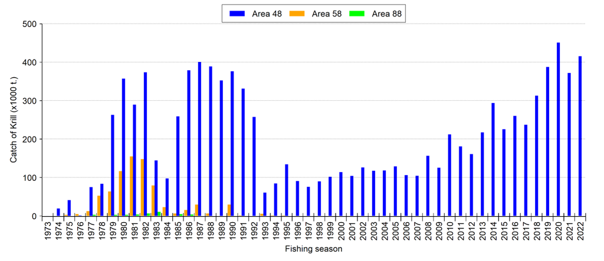

Annual catches of Antarctic krill (*Euphausia superba*) in the CAMLR Convention Area (CCAMLR Secretariat 2023a)

**M**: The instantaneous rate of natural mortality. For each simulation a single value is drawn from a uniform distribution specified by the upper and lower bounds provided. Uniform distribution lower and upper bounds. Non-negative real numbers.

Specified in cpars: 0.563, 1.291

Simulation values for **M** provided in cpars (see Custom Parameters). The text above on values being drawn from an uniform distribution should be ignored.

**Msd**: Inter-annual variation in M expressed as a coefficient of variation of a log-normal distribution. For each simulation a single value is drawn from a uniform distribution specified by the upper and lower bounds provided. If this parameter is positive, yearly M is drawn from a log-normal distribution with a mean specified by log(M) drawn for that simulation and a standard deviation in log space specified by the value of Msd drawn for that simulation. Uniform distribution lower and upper bounds. Non-negative real numbers

Specified Value(s): 0, 0

Assuming natural mortality in krill is constant over time, in alignment with assumptions taken in previous stock assessment analysis (D. Maschette et al. 2021).

### Natural Mortality Parameters

#### Sampled Parameters

Histograms of simulations of `M`, and `Msd` parameters, with vertical colored lines indicating 3 randomly drawn values used in other plots:

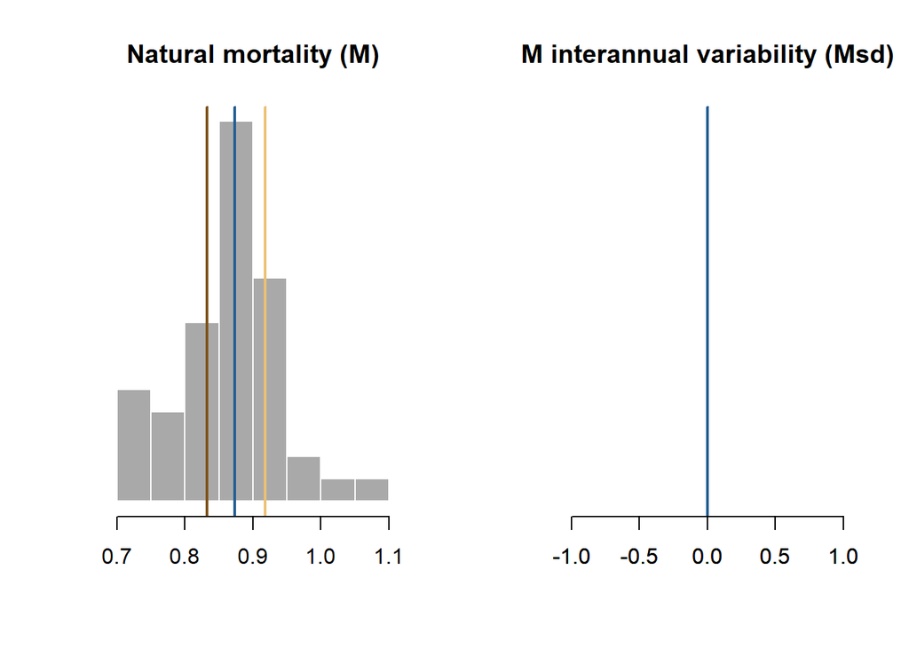

#### Time-Series

The average natural mortality rate by year for adult fish for 3 simulations. The vertical dashed line indicates the end of the historical period:

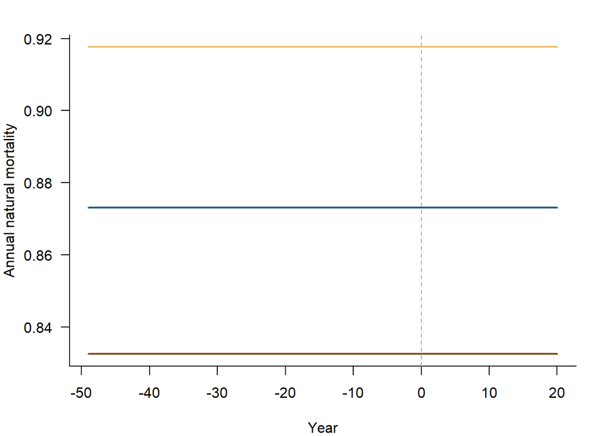

#### M-at-Age

Natural mortality-at-age for 3 simulations in the first historical year, the last historical year (i.e., current year), and the last projected year:

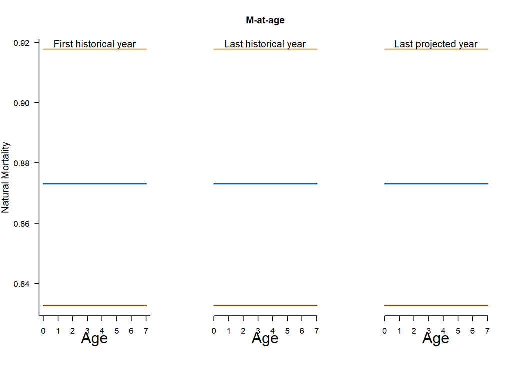

#### M-at-Length

Natural mortality-at-length for 3 simulations in the first historical year, the last historical year (i.e., current year), and the last projected year:

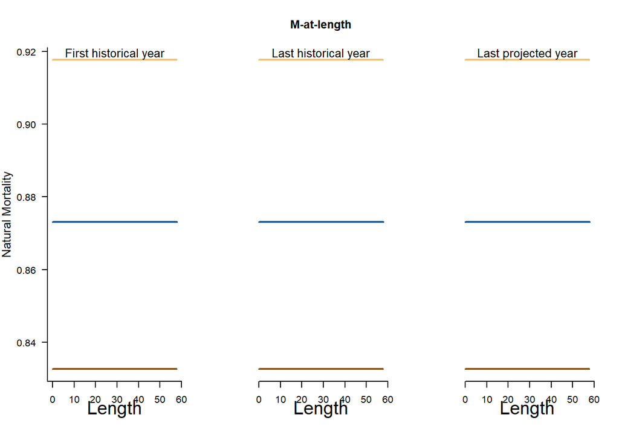

### Recruitment: h, SRrel, Perr, AC

**h**: Steepness of the stock recruit relationship. Steepness governs the proportion of unfished recruits produced when the stock is at 20% of the unfished population size. For each simulation a single value is drawn from a uniform distribution specified by the upper and lower bounds provided. This value is the same in all years of a given simulation. Uniform distribution lower and upper bounds. Values from 1/5 to 1.

Specified Value(s): 0.9, 0.95

Studies such as those presented in V. Siegel and Loeb (1995) and Kinzey, Watters, and Reiss (2019) have demonstrated the lack of a strong relationship between spawning biomass and recruitment levels in krill populations. In fact, sensitivity analysis in stock assessments showed models presenting better fits to the data when recruitment was treated as random with respect to spawning stock biomass (Kinzey, Watters, and Reiss 2019). This weak dependency has been primarily attributed to the significant inter-annual variability in biomass of spawners and recruits, believed to be heavily driven by environmental factors.

Therefore, a range of high **h** values was specified to express a weak stock-recruitment relationship. As demonstrated in [Chapter 3](https://dmpstats.github.io/krill_mse/part1_openMSE_GRYM_approx/3_openMSE_sims/openmse_sims.html) of the current project, these values also offer a reliable approximation of the Grym model currently employed in the management of the krill fishery. When **h** values approach 1, the resulting stock-recruitment curves display marked concavity, expressing a rapid increase in mean recruitment as stock size rises from low levels, swiftly reaching an asymptotic limit. Consequently, simulated recruitment values exhibit a near independent relationship with stock size, except when the stock is at or below 20% of its unexploited size.

**SRrel**: Type of stock-recruit relationship. Use 1 to select a Beverton Holt relationship, 2 to select a Ricker relationship. Single value. Integer

Specified Value(s): 1

Kinzey, Watters, and Reiss (2019) showed no clear advantage in favoring either the Beverton-Holt function or the Ricker model to describe the stock-recruitment relationship in krill. Moreover, previous assessments of krill (e.g. D. Maschette et al. 2021) did not incorporate density dependence as a factor influencing recruitment success. Therefore, the Beverton–Holt model was assumed to be a suitable choice for a base-case OM for krill.

**Perr**: Recruitment process error, which is defined as the standard deviation of the recruitment deviations in log space. For each simulation a single value is drawn from a uniform distribution specified by the upper and lower bounds provided. Uniform distribution lower and upper bounds. Non-negative real numbers.

Specified in cpars: 0.255, 1.183

Simulation values of **Perr** provided in cpars (see Custom Parameters). The text above about values being drawn from an uniform distribution should be ignored.

**AC**: Autocorrelation in the recruitment deviations in log space. For each simulation a single value is drawn from a uniform distribution specified by the upper and lower bounds provided, and used to add lag-1 auto-correlation to the log recruitment deviations. Uniform distribution lower and upper bounds. Non-negative real numbers.

Specified Value(s): 0, 0

Assuming no autocorrelation between consecutive annual recruitments, as in previous population assessments and recruitment-related studies applied to krill (D. Maschette et al. 2021; Kinzey, Watters, and Reiss 2019).

### Recruitment Parameters

#### Sampled Parameters

Histograms of 48 simulations of steepness (`h`), recruitment process error (`Perr`) and auto-correlation (`AC`) for the Beverton-Holt stock-recruitment relationship, with vertical colored lines indicating 3 randomly drawn values used in other plots:

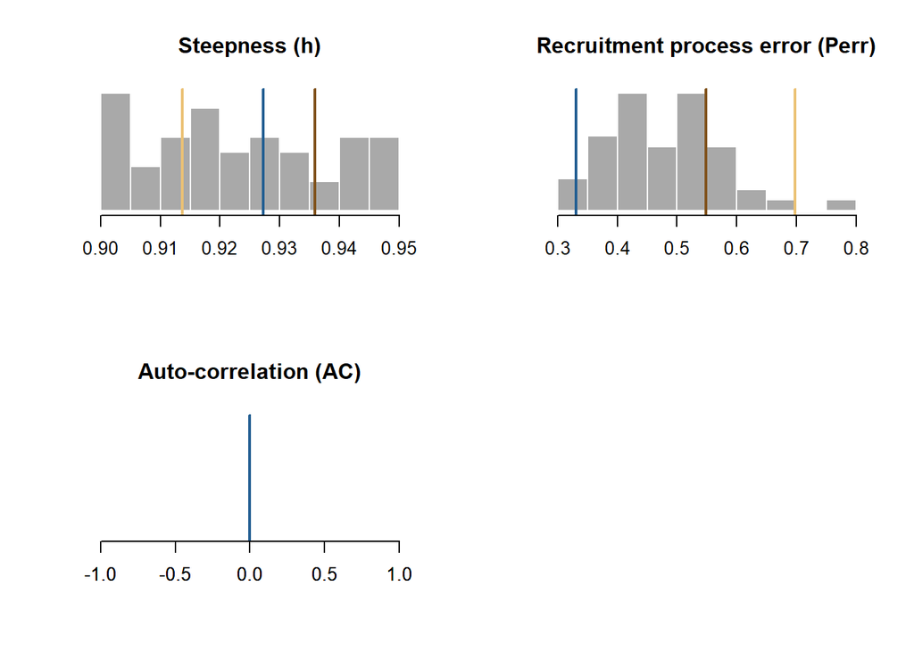

#### Time-Series

Time-series plot showing 3 samples of recruitment deviations for historical and projection years:

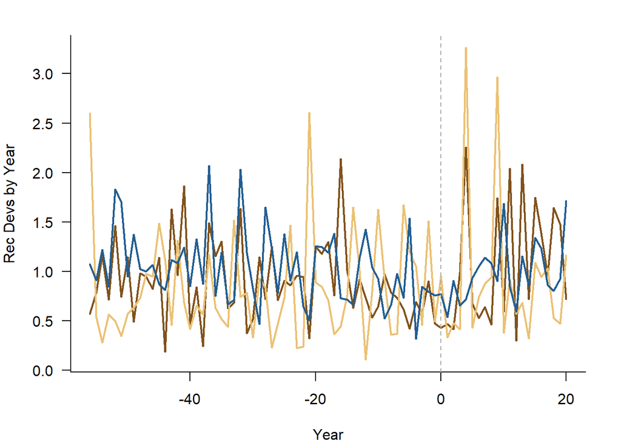

### Growth: Linf, K, t0, LenCV, Ksd, Linfsd

**Linf**: The von Bertalanffy growth parameter Linf, which specifies the average maximum size that would reached by adult fish if they lived indefinitely. For each simulation a single value is drawn from a uniform distribution specified by the upper and lower bounds provided. This value is the same in all years unless Linfsd is a positive number. Uniform distribution lower and upper bounds. Positive real numbers.

Specified Value(s): 60, 61

Lower and upper bounds based on estimates from, respectively, V. Siegel (1987) and Constable and de la Mare (1996), in millimeters.

**K**: The von Bertalanffy growth parameter k, which specifies the average rate of growth. For each simulation a single value is drawn from a uniform distribution specified by the upper and lower bounds provided. This value is the same in all years unless Ksd is a positive number. Uniform distribution lower and upper bounds. Positive real numbers.

Specified Value(s): 0.45, 0.48

Range of values defined to cover estimates presented in V. Siegel (1987), Constable and de la Mare (1996) and Thanassekos et al. (2021).

**t0**: The von Bertalanffy growth parameter t0, which specifies the theoretical age at a size 0. For each simulation a single value is drawn from a uniform distribution specified by the upper and lower bounds provided. Uniform distribution lower and upper bounds. Non-positive real numbers.

Lower and upper bound defined by estimates presented in, respectively, Constable and de la Mare (1996) and V. Siegel (1987).

**LenCV**: The coefficient of variation (defined as the standard deviation divided by mean) of the length-at-age. For each simulation a single value is drawn from a uniform distribution specified by the upper and lower bounds provided to specify the distribution of observed length-at-age, and the CV of this distribution is constant for all age classes (i.e, standard deviation increases proportionally with the mean). Uniform distribution lower and upper bounds. Positive real numbers.

Specified Value(s): 0.05, 0.08

No actual data found regarding the variance of length-at-age in krill. Models used by D. Maschette et al. (2021) did not considered variability in lengths-at-age, therefore assuming that all individuals follow precisely the average growth curve. This is a reasonable assumption whithin the context of a daily time-steps population dynamics model like Grym. In contrast, openMSE/MSEtool simulations operate on a year-based population dynamics model, where length is expected to vary within each age-class to some extent.

Range of **LenCV** values chosen to express a low level of variability in length-at-age.

**Ksd**: Inter-annual variation in K. For each simulation a single value is drawn from a uniform distribution specified by the upper and lower bounds provided. If this parameter has a positive value, yearly K is drawn from a log-normal distribution with a mean specified by the value of K drawn for that simulation and a standard deviation (in log space) specified by the value of Ksd drawn for that simulation. Uniform distribution lower and upper bounds. Non-negative real numbers.

Specified Value(s): 0, 0

No data found on variability in growth patterns over time. Assuming no inter-annual variation in growth parameter $K$.

**Linfsd**: Inter-annual variation in Linf. For each simulation a single value is drawn from a uniform distribution specified by the upper and lower bounds provided. If this parameter has a positive value, yearly Linf is drawn from a log-normal distribution with a mean specified by the value of Linf drawn for that simulation and a standard deviation (in log space) specified by the value of Linfsd drawn for that simulation. Uniform distribution lower and upper bounds. Non-negative real numbers.

Specified Value(s): 0, 0

No data found on temporal variability in growth over time. Assuming no inter-annual variation in $L_\infty$.

### Growth Parameters

#### Sampled Parameters

Histograms of simulations of von Bertalanffy growth parameters `Linf`, `K`, and `t0`, and inter-annual variability in Linf and K (`Linfsd` and `Ksd`), with vertical colored lines indicating 3 randomly drawn values used in other plots:

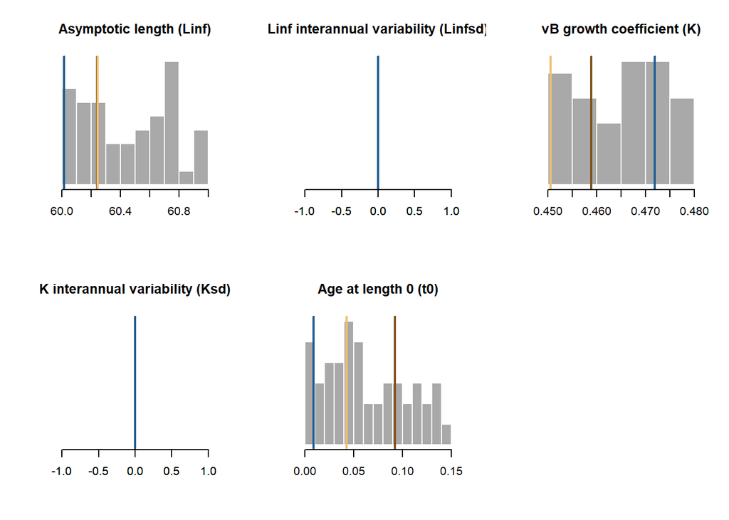

#### Time-Series

The Linf and K parameters in each year for 3 simulations. The vertical dashed line indicates the end of the historical period:

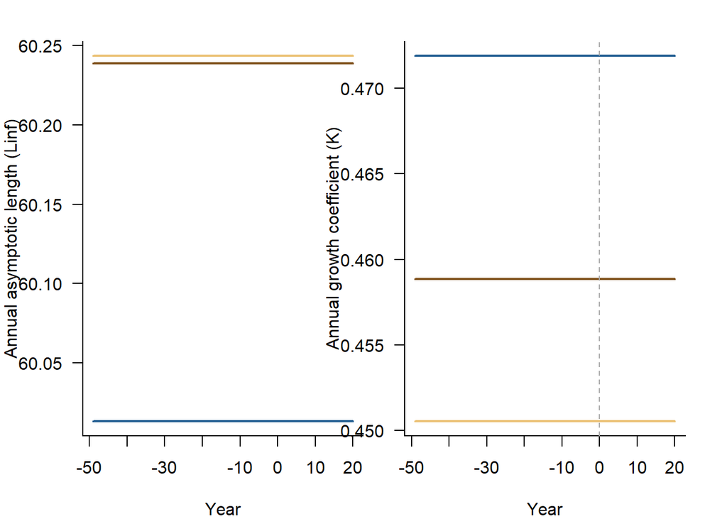

#### Growth Curves

Sampled length-at-age curves for 3 simulations in the first historical year, the last historical year, and the last projection year.

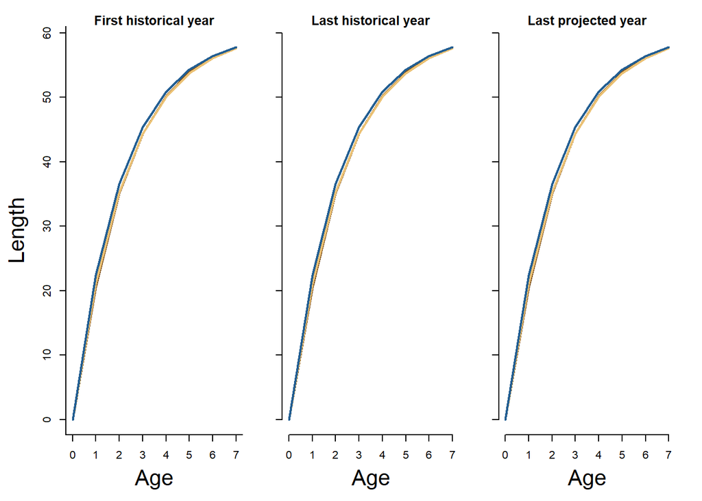

### Maturity: L50, L50_95

**L50**: Length at 50% maturity. For each simulation a single value is drawn from a uniform distribution specified by the upper and lower bounds provided. The L50 and L50_95 parameters are converted to ages using the growth parameters provided and used to construct a logistic curve to determine the proportion of the population that is mature in each age class. Uniform distribution lower and upper bounds. Positive real numbers.

Specified Value(s): 37.6, 44.3

Lower and upper bound values obtained from estimates of minimum and maximum length (mm) at 50% maturity presented in D. Maschette et al. (2021). The width and slope of a ramp-shaped maturity ogive were estimated by fitting a Bayesian non-linear random-effects model using a relatively large time-series of data (D. Maschette et al. 2021).

**L50_95**: Difference in lengths between 50% and 95% maturity. For each simulation a single value is drawn from a uniform distribution specified by the upper and lower bounds provided. The value drawn is then added to the length at 50% maturity to determine the length at 95% maturity. This parameterization is used instead of specifying the size at 95 percent maturity to avoid situations where the value drawn for the size at 95% maturity is smaller than that at 50% maturity. The L50 and L50_95 parameters are converted to ages using the growth parameters provided and used to construct a logistic curve to determine the proportion of the population that is mature in each age class. Uniform distribution lower and upper bounds. Positive real numbers.

Specified Value(s): 3.96, 3.96

Maturity-at-length estimates presented in D. Maschette et al. (2021) were based on a ramp-shaped ogive, which takes the ramp’s width `matrange` (i.e. the range over which maturity occurs) as one of the defining parameters. Thus, `L95` (length at which 95% of individuals are matures) can be derived via the quantile function of the uniform distribution with limits `L50 +- matrange/2`.

For an estimated width of 8.8mm (D. Maschette et al. 2021), we derive the `L50_95` parameter value as follows:

```r
matrange <- 8.8
L50 <- 40 # arbitrary as `matrange` is treated as independent of midpoint L50 in Maschette et al (2021)
L95 <- qunif(0.95, L50 - matrange/2, L50 + matrange/2)
L95 - L50
```

```
## [1] 3.96
```

Similarly to the assumptions taken in the Grym models applied in D. Maschette et al. (2021), where `matrange` is treated as known, **L50_95** is also kept fixed across simulations.

### Maturity Parameters

#### Sampled Parameters

Histograms of simulations of `L50` (length at 50% maturity), and `L95` (length at 95% maturity), with vertical colored lines indicating 3 randomly drawn values used in other plots:

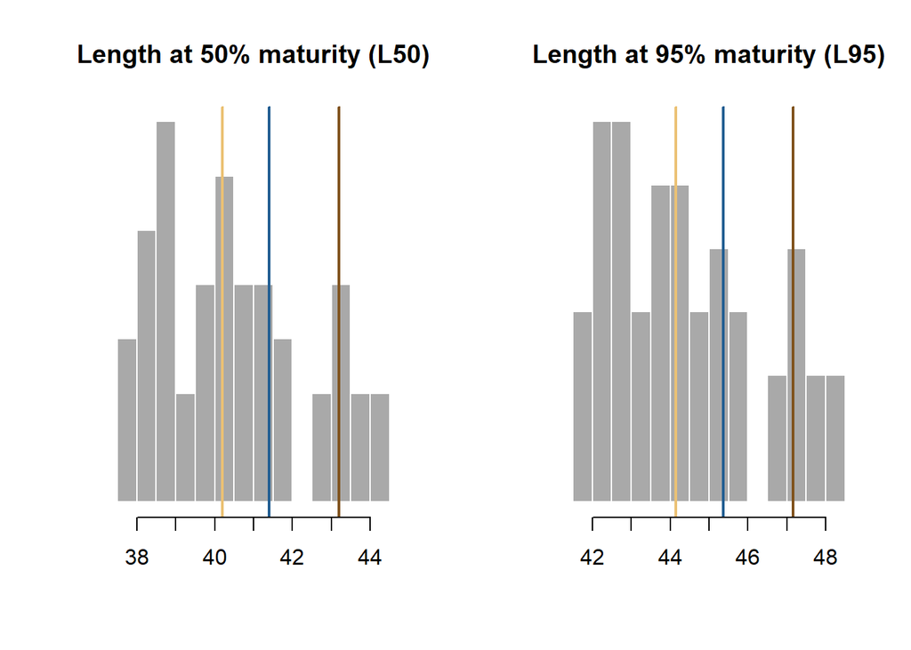

#### Maturity at Age and Length

Maturity-at-age and -length for 3 simulations in the first historical year, the last historical year (i.e., current year), and the last projected year:

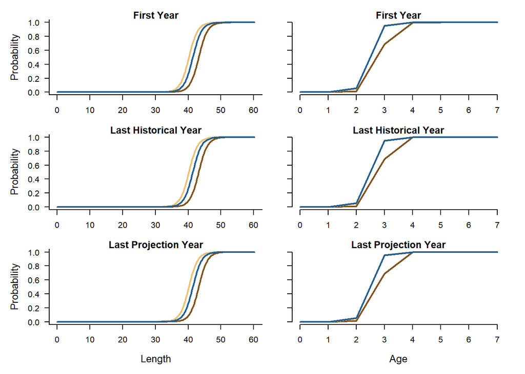

### Stock depletion and Discard Mortality: D, Fdisc

**D**: Estimated current level of stock depletion, which is defined as the current spawning stock biomass divided by the unfished spawning stock biomass. For each simulation a single value is drawn from a uniform distribution specified by the upper and lower bounds provided. This parameter is used during model initialization to select a series of yearly historical recruitment values and fishing mortality rates that, based on the information provided, could have resulted in the specified depletion level in the simulated last historical year. Uniform distribution lower and upper bounds. Positive real numbers (typically < 1)

Specified Value(s): 1, 1

Arbitrary values as depletion optimization step is not carried out (see Depletion optimization section above).

**Fdisc**: The instantaneous discard mortality rate the stock experiences when fished using the gear type specified in the corresponding fleet object and discarded. For each simulation a single value is drawn from a uniform distribution specified by the upper and lower bounds provided. Uniform distribution lower and upper bounds. Non-negative real numbers.

Specified Value(s): 0, 0

Zero discard mortality rate, as discards are assumed non-existent in the Krill fishery.

### Depletion and Discard Mortality

#### Sampled Parameters

Histograms of simulations of depletion (spawning biomass in the last historical year over average unfished spawning biomass; `D`) and the fraction of discarded fish that are killed by fishing mortality (`Fdisc`), with vertical colored lines indicating 3 randomly drawn values.

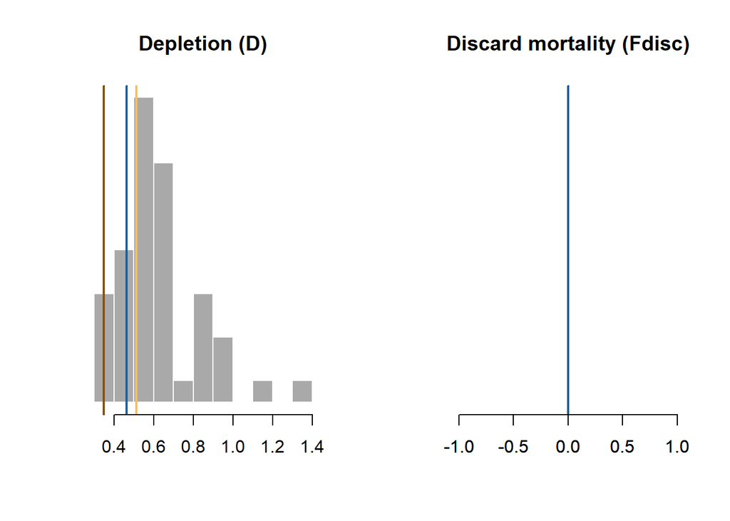

### Length-weight conversion parameters: a, b

**a**: The alpha parameter in allometric length-weight relationship. Single value. Weight parameters are used to determine catch-at-age and population-at-age from the number of individuals in each age class and the length of each individual, which is drawn from a normal distribution determined by the Linf , K , t0 , and LenCV parameters. As a result, they function as a way to scale between numbers at age and biomass, and are not stochastic parameters. Single value. Positive real number.

Specified Value(s): 0

Value estimated from an acoustic survey conducted in Area 48 in 2020, as presented in D. Maschette et al. (2021).

**b**: The beta parameter in allometric length-weight relationship. Single value. Weight parameters are used to determine catch-at-age and population-at-age from the number of individuals in each age class and the length of each individual, which is drawn from a normal distribution determine by the Linf , K , t0 , and LenCV parameters. As a result, they function as a way to scale between numbers at age and biomass, and are not stochastic parameters. Single value. Positive real number.

Specified Value(s): 3.24

Value estimated from an acoustic survey conducted in Area 48 in 2020, as presented in D. Maschette et al. (2021).

### Spatial distribution and movement: Size_area_1, Frac_area_1, Prob_staying

**Size_area_1**: The size of area 1 relative to area 2. The fraction of the unfished biomass in area 1. Please specify numbers between 0 and 1. For each simulation a single value is drawn from a uniform distribution specified by the upper and lower bounds provided. For example, if Size_area_1 is 0.2, then 20% of the total area is allocated to area 1. Fishing can occur in both areas, or can be turned off in one area to simulate the effects of a no take marine reserve. Uniform distribution lower and upper bounds. Positive real numbers.

Specified Value(s): 0.5, 0.5

This example base-case OM is intended to cover the whole FAO 48 area. Ideally, parameter value would be specified to be 1 (i.e. forcing simulations to a single study area). However **Size_area_1** is not allowed to be 1, so specifying that the two sub-areas have equal size.

**Frac_area_1**: The fraction of the unfished biomass in area 1. Please specify numbers between 0 and 1. For each simulation a single value is drawn from a uniform distribution specified by the upper and lower bounds provided. For example, if Frac_area_1 is 0.5, then 50% of the unfished biomass is allocated to area 1, regardless of the size of area 1 (i.e, size and fraction in each area determine the density of fish, which may impact fishing spatial targeting). In each time step recruits are allocated to each area based on the proportion specified in Frac_area_1. Uniform distribution lower and upper bounds. Positive real numbers.

Specified Value(s): 0.5, 0.5

This example base-case OM is intended to cover the whole FAO 48 area. Ideally, parameter value would be specified to be 1 (i.e. forcing simulations to a single study area). However **Frac_area_1** is not allowed to be 1, so specifying that population is evenly split between the two sub-areas.

**Prob_staying**: The probability of individuals in area 1 remaining in area 1 over the course of one year. Please specify numbers between 0 and 1. For each simulation a single value is drawn from a uniform distribution specified by the upper and lower bounds provided. For example, in an area with a Prob_staying value of 0.95 each fish has a 95% probability of staying in that area in each time step, and a 5% probability of moving to the other area. Uniform distribution lower and upper bounds. Positive fraction.

Specified Value(s): 0.5, 0.5

This example base-case OM is intended to cover the whole FAO 48 area. Ideally, parameter value would be specified to be 1 (i.e. forcing simulations to a single study area). However **Prob_staying** is not allowed to be 1, so assuming 50% chance of movement between sub-areas.

### Spatial & Movement

#### Sampled Parameters

Histograms of 48 simulations of size of area 1 (`Size_area_1`), fraction of unfished biomass in area 1 (`Frac_area_1`), and the probability of staying in area 1 in a year (`Frac_area_1`), with vertical colored lines indicating 3 randomly drawn values used in other plots:

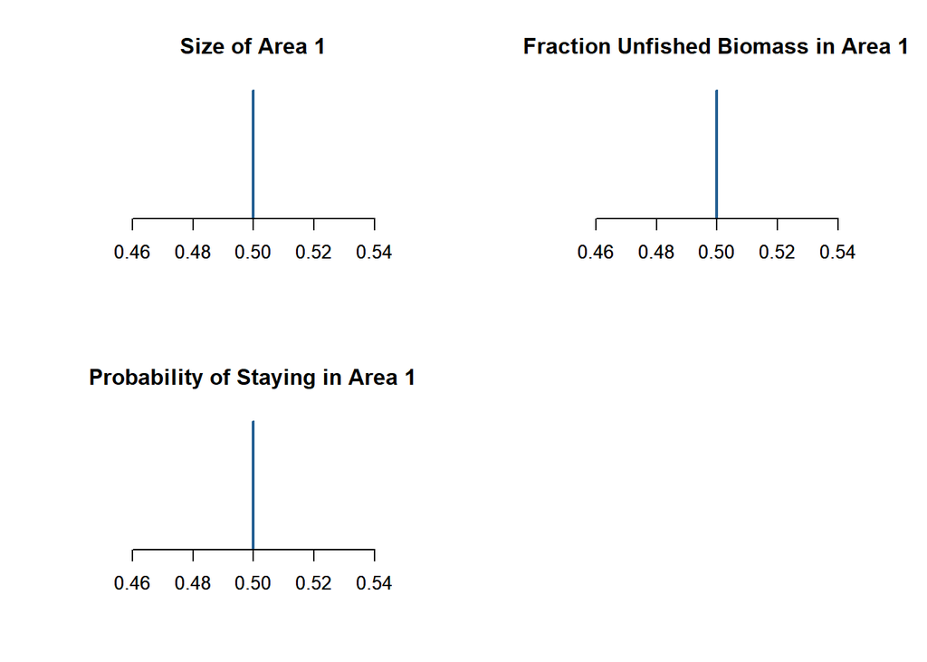

# Fleet Parameters

### Historical years of fishing, spatial targeting: nyears, Spat_targ

**nyears**: The number of years for the historical simulation. Single value. For example, if the simulated population is assumed to be unfished in 1975 and this is the year you want to start your historical simulations, and the most recent year for which there is data available is 2019, then nyears equals 45.

Specified Value(s): 50

Set based on the length of time-series of catch and effort data for the krill fishery in the whole Statistical Area 48, available in CCAMLR Secretariat (2023b).

**Spat_targ**: Distribution of fishing in relation to vulnerable biomass (VB) across areas. The distribution of fishing effort is proportional to VB^Spat_targ. Upper and lower bounds of a uniform distribution. For each simulation a single value is drawn from a uniform distribution specified by the upper and lower bounds provided. This parameter allows the user to model either avoidance or spatial targeting behavior by the fleet. If the parameter value is 1, fishing effort is allocated across areas in proportion to the population density of that area. Values below 1 simulate an avoidance behavior and values above 1 simulate a targeting behavior.

Specified Value(s): 1, 1

Assuming fishing effort is allocated across areas in proportion to the population density in each area.

### Trend in historical fishing effort (exploitation rate), interannual variability in fishing effort: EffYears, EffLower, EffUpper, Esd

**EffYears**: Vector indicating the historical years where there is information available to infer the relative fishing effort expended.This vector is specified in terms of the position of the year in the vector rather than the calendar year. For example, say our simulation starts with an unfished stock in 1975,and the current year (the last year for which there is data available) is 2019. Then there are 45 historical years simulated, and EffYears should include numbers between 1 and 45. Note that there may not be information available for every historical year, especially for data poor fisheries. In these situations, the EffYears vector should include only the positions of the years for which there is information, and the vector may be shorter than the total number of simulated historical years (nyears).

Extracted from the time-series of effort targeted at Krill in Area 48 provided by CCAMLR Secretariat (2023b). The original time-series indicates non-existed (zero) effort for the years 1976, 1978 and 1979, despite the reported catches in those years. Therefore, in these years, effort is treated as unknown .

**EffLower**: Lower bound on relative fishing effort corresponding to EffYears. EffLower must be a vector that is the same length as EffYears describing how fishing effort has changed over time. Information on relative fishing effort can be entered in any units provided they are consistent across the entire vector because the data provided will be scaled to 1 (divided by the maximum number provided).

Yearly time-series of effort in terms of duration of trawling (unit: hours) across all vessels targeting Krill and operating in the whole Statistical Area 48, as available in CCAMLR Secretariat (2023b). Trawling duration at vessel-level is the sum over each operating net at a haul-by-haul scale.

**EffUpper**: Upper bound on relative fishing effort corresponding to EffYears. EffUpper must be a vector that is the same length as EffYears describing how fishing effort has changed over time. Information on relative fishing effort can be entered in any units provided they are consistent across the entire vector because the data provided will be scaled to 1 (divided by the maximum number provided).

Same values as those specified for **EffLower**, i.e. reported effort assumed to be accurate (i.e. known without error).

| EffYears | EffLower | EffUpper |
| --- | --- | --- |
| 1973 | 4 | 4 |
| 1974 | 186 | 186 |
| 1975 | 191 | 191 |
| 1977 | 402 | 402 |
| 1980 | 87 | 87 |
| 1981 | 259 | 259 |
| 1982 | 514 | 514 |
| 1983 | 18100 | 18100 |
| 1984 | 6100 | 6100 |
| 1985 | 36000 | 36000 |
| 1986 | 59000 | 59000 |
| 1987 | 65200 | 65200 |
| 1988 | 64000 | 64000 |
| 1989 | 56900 | 56900 |
| 1990 | 99200 | 99200 |
| 1991 | 53900 | 53900 |
| 1992 | 27400 | 27400 |
| 1993 | 5480 | 5480 |
| 1994 | 8510 | 8510 |
| 1995 | 12400 | 12400 |
| 1996 | 11900 | 11900 |
| 1997 | 10200 | 10200 |
| 1998 | 9390 | 9390 |
| 1999 | 11100 | 11100 |
| 2000 | 9650 | 9650 |
| 2001 | 8630 | 8630 |
| 2002 | 8860 | 8860 |
| 2003 | 6910 | 6910 |
| 2004 | 10500 | 10500 |
| 2005 | 8330 | 8330 |
| 2006 | 6430 | 6430 |
| 2007 | 5460 | 5460 |
| 2008 | 8110 | 8110 |
| 2009 | 5490 | 5490 |
| 2010 | 18800 | 18800 |
| 2011 | 20600 | 20600 |
| 2012 | 17100 | 17100 |
| 2013 | 25600 | 25600 |
| 2014 | 28400 | 28400 |
| 2015 | 30200 | 30200 |
| 2016 | 28300 | 28300 |
| 2017 | 23400 | 23400 |
| 2018 | 25900 | 25900 |
| 2019 | 22400 | 22400 |
| 2020 | 47300 | 47300 |
| 2021 | 36100 | 36100 |
| 2022 | 34400 | 34400 |

**Esd**: Additional inter-annual variability in fishing mortality rate. For each historical simulation a single value is drawn from a uniform distribution specified by the upper and lower bounds provided. If this parameter has a positive (non-zero) value, the yearly fishing mortality rate is drawn from a log-normal distribution with a standard deviation (in log space) specified by the value of Esd drawn for that simulation. This parameter applies only to historical projections.

Specified Value(s): 0, 0

Assuming no extra variability in fishing mortality.

### Historical Effort

#### Sampled Parameters

Histograms of 48 simulations of inter-annual variability in historical fishing mortality (`Esd`), with vertical colored lines indicating 3 randomly drawn values used in the time-series plot:

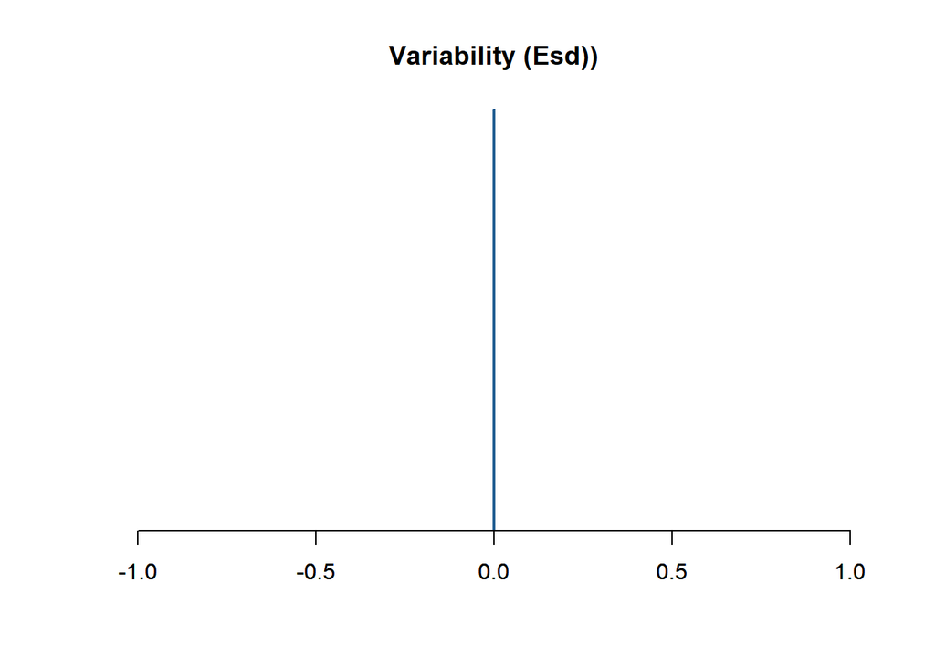

#### Time-Series

Time-series plot showing 3 trends in historical fishing mortality (`OM@EffUpper` and `OM@EffLower` or `OM@cpars$Find`):

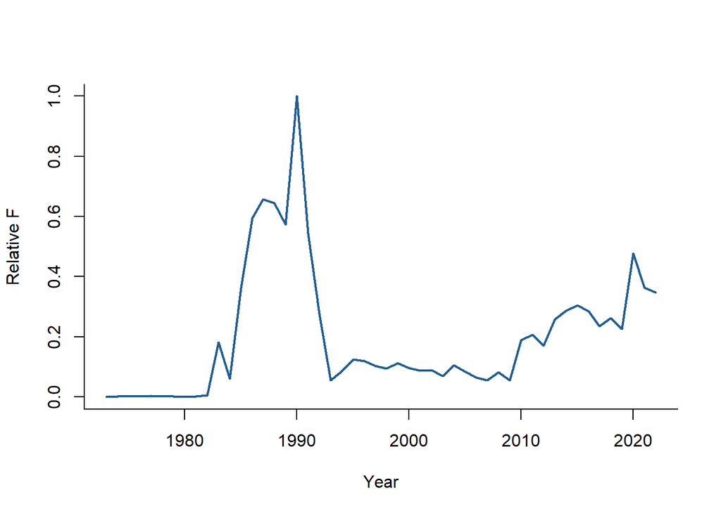

### Annual increase in catchability, interannual variability in catchability: qinc, qcv

**qinc**: Mean temporal trend in catchability (also though of as the efficiency of fishing gear) parameter, expressed as a percentage change in catchability (q) per year. For each simulation a single value is drawn from a uniform distribution specified by the upper and lower bounds provided. Positive numbers indicate an increase and negative numbers indicate a decrease. q then changes by this amount for in each year of the simulation This parameter applies only to forward projections.

Specified Value(s): 0, 0

Assuming no change in gear efficiency over the projection period under the base-case OM.

**qcv**: Inter-annual variability in catchability expressed as a coefficient of variation. For each simulation a single value is drawn from a uniform distribution specified by the upper and lower bounds provided. This parameter applies only to forward projections.

Specified Value(s): 0.05, 0.08

No historic data found on inter-annual variability in gear efficiency with respect to the krill fishery.

Allowing for an arbitrary low level of variability in fishing efficiency during the projection period, to account for annual deviations from mean catchability due to weather-related events.

### Future Catchability

#### Sampled Parameters

Histograms of 48 simulations of inter-annual variability in fishing efficiency (`qcv`) and average annual change in fishing efficiency (`qinc`), with vertical colored lines indicating 3 randomly drawn values used in the time-series plot:

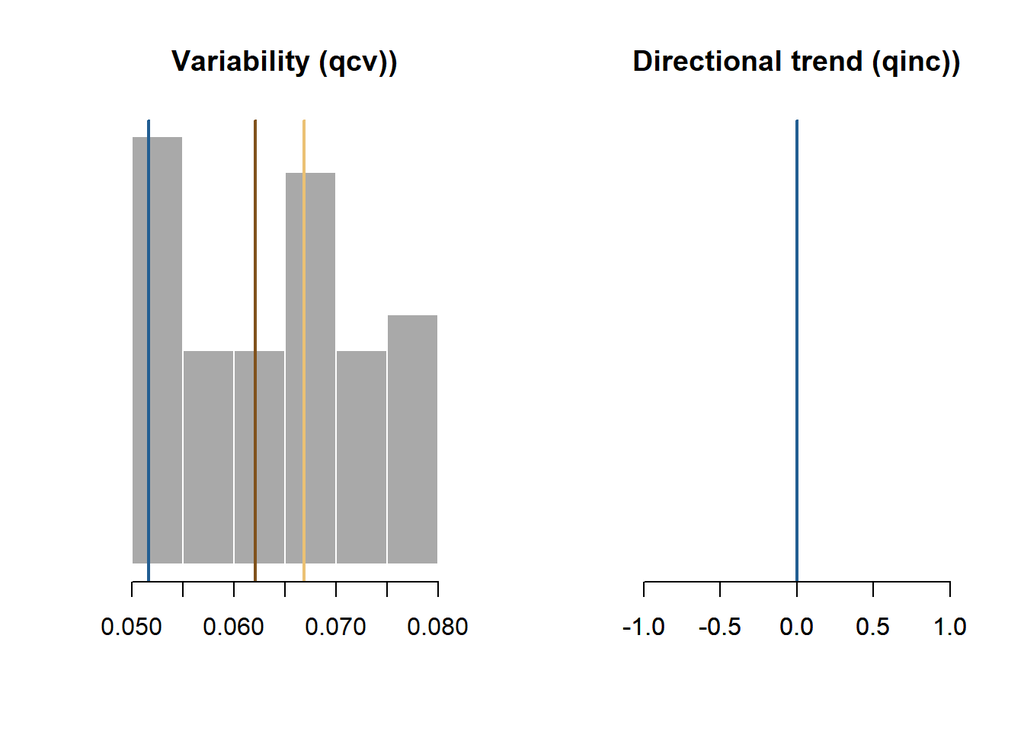

#### Time-Series

Time-series plot showing 3 trends in future fishing efficiency (catchability):

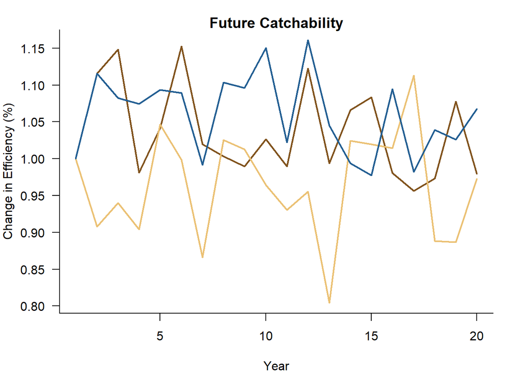

### Fishery gear length selectivity: L5, LFS, Vmaxlen, isRel

**L5**: Shortest length at which 5% of the population is vulnerable to selection by the gear used in this fleet. Values can either be specified as lengths (in the same units used for the maturity and growth parameters in the stock object) or as a percentage of the size of maturity (see the parameter isRel for more information). For each simulation a single value is drawn from a uniform distribution specified by the upper and lower bounds provided. This value is the same in all years unless cpars is used to provide time-varying selection.

Specified Value(s): 23.8, 28.54

Specified values based on estimates presented in Krag et al. (2014, Table 6), corresponding to the 95% confidence limits of length at which the probability of individuals being retained by the fishing gear is 5%.

**LFS**: Shortest length at which 100% of the population is vulnerable to selection by the gear used by this fleet. Values can either be specified as lengths (in the same units used for the maturity and growth parameters in the stock object) or as a percentage of the size of maturity (see the parameter isRel for more information). For each simulation a single value is drawn from a uniform distribution specified by the upper and lower bounds provided. This value is the same in all years unless cpars is used to provide time-varying selection.

Specified Value(s): 42.35, 56.85

Values derived from estimates of selectivity parameters L50 (length at which there is 50% probability of gear retention) and SR (selection range, i.e. L75-L25) presented in Krag et al. (2014, Table 7). In the absence of estimates of L100 in the same source, specified values are the boundaries of the 95% quantile interval obtained from bootstrap estimates. These estimates of L100 were derived by resampling L50 and SR (assumed to be normally distributed), and calculating shortest length at retention probability of 100% based on the logistic model used in Krag et al. (2014).

**Vmaxlen**: Proportion of fish selected by the gear at the asymptotic length (‘Stock@Linf’). Upper and Lower bounds between 0 and 1. A value of 1 indicates that 100% of fish are selected at the asymptotic length, and the selection curve is logistic. If Vmaxlen is less than 1 the selection curve is dome shaped. For example, if Vmaxlen is 0.4, then only 40% of fish are vulnerable to the fishing gear at the asymptotic length.

Specified Value(s): 1, 1

Values derived by bootstrapping (95% quantile interval) based on the selectivity logistic model and parameter estimates presented in Krag et al. (2014, Table 7), taking the mid-point of values specified above for parameter **Linf**.

**isRel**: Specify whether selection and retention parameters use absolute lengths or relative to the size of maturity. Single logical value (TRUE or FALSE).

Specified Value(s): FALSE

Selectivity parameters are in absolute units.

### Fishery length retention: LR5, LFR, Rmaxlen, DR

**LR5**: Shortest length at which 5% of the population is vulnerable to retention by the fleet. Values can either be specified as lengths (in the same units used for the maturity and growth parameters in the stock object) or as a percentage of the size of maturity (see the parameter isRel for more information). For each simulation a single value is drawn from a uniform distribution specified by the upper and lower bounds provided. This value is the same in all years unless cpars is used to provide time-varying selection.

Specified Value(s): 0, 0

Analogously to previous stock assessment analysis (e.g. D. Maschette et al. 2021), assuming no discards in the krill fishery - i.e. all individuals selected by the gear are retained.

**LFR**: Shortest length where 100% of the population is vulnerable to retention by the fleet. Values can either be specified as lengths (in the same units used for the maturity and growth parameters in the stock object) or as a percentage of the size of maturity (see the parameter isRel for more information). For each simulation a single value is drawn from a uniform distribution specified by the upper and lower bounds provided. This value is the same in all years unless cpars is used to provide time-varying selection.

Specified Value(s): 0, 0

Idem to **LR5** - Assuming no discards and hence all individuals selected by the gear are retained.

**Rmaxlen**: Proportion of fish retained at the asymptotic length (‘Stock@Linf’). Upper and Lower bounds between 0 and 1. A value of 1 indicates that 100% of fish are retained at the asymptotic length, and the selection curve is logistic. If Rmaxlen is less than 1 the retention curve is dome shaped. For example, if Rmaxlen is 0.4, then only 40% of fish at the asymptotic length are retained.

Specified Value(s): 1, 1

Same as **Vmaxlen**, i.e. 100% of fish are retained at $L_{\infty}$.

**DR**: Discard rate, defined as the proportion of fully selected fish that are discarded by the fleet. Upper and Lower bounds between 0 and 1, with a value of 1 indicates that 100% of selected fish are discarded. For each simulation a single value is drawn from a uniform distribution specified by the upper and lower bounds provided.

Specified Value(s): 0, 0

Assuming no discards.

### Current Year: CurrentYr

**CurrentYr**: The last historical year simulated before projections begin. Single value. Note that this should match the last historical year specified in the Data object, which is usually the last historical year for which data is available.

Specified Value(s): 2022

Latest year with available fishing effort data.

### Existing Spatial Closures: MPA

**MPA**: Logical argument (TRUE or FALSE). Creates an MPA in Area 1 for all years if true is selected. Defaults to FALSE.

Specified Value(s): FALSE

Both areas assumed to be open to fishing at all times.

# Obs Parameters

Due to the scarcity of data from the Krill fishery to guide the specification of parameters defining the observational model, many values assumed in this section are arbitrary. Consequently, some of these parameter values may be deemed unrealistic by other fishery stakeholders and experts.In establishing this base-case Operating Model (OM), we opted to assume the absence directional bias in the all elements associated with data collection and fishing activity reporting. Potential bias linked to some of the observed quantities will be evaluated through robustness testing.

### Catch statistics: Cobs, Cbiascv, CAA_nsamp, CAA_ESS, CAL_nsamp, CAL_ESS

**Cobs**: Observation error around the total catch. Observation error in the total catch is expressed as a coefficient of variation (CV). Cobs requires upper and lower bounds of a uniform distribution, and for each simulation a CV is sampled from this distribution. Each CV is used to specify a log-normal error distribution with a mean of 1 and a standard deviation equal to the sampled CV. The yearly observation error values for the catch data are then drawn from this distribution. For each time step the simulation model records the true catch, but the observed catch is generated by applying this yearly error term (plus any bias, if specified) to the true catch.

Specified Value(s): 0.05, 0.1

No data found on the extent of error in catch reporting for the krill fishery. Catches are reported in terms of “green-weight”, which are estimated by applying a conversion factor to the mass of the landed product (CCAMLR Secretariat 2023a). Conversion factors are specific to on-board processing methods used by vessels, introducing uncertainties in the estimation of green weight that must considered when assessing the status of the stock. Although the estimation of green weight remains a topic of interest to the CCAMLR Scientific Committee (CCAMLR Secretariat 2023a), estimates of error in reported catches are still unavailable.

Assuming a low level of error with a CV between 5% and 10%.

**Cbiascv**: Log-normally distributed coefficient of variation controlling the sampling bias in observed catch for each simulation. Bias occurs when catches are systematically skewed away from the true catch level (for example, due to underreporting of catch or undetected illegal catches). Cbiascv is a single value specifying the standard deviation of a log-normal distribution with a mean of 1 and a standard deviation equal to the sampled CV. For each simulation a bias value is drawn from this distribution, and that bias is applied across all years.

Specified Value(s): 0

Catch reporting assumed to be unbiased. As noted in CCAMLR Secretariat (2023a), illegal, unreported and unregulated (IUU) fishing for krill in Statistical Area 48 has not been reported by independent on-board observers to date.

**CAA_nsamp**: Number of catch-at-age observations collected per time step. For each time step a single value is drawn from a uniform distribution specified by the upper and lower bounds provided. Positive integers.

Specified Value(s): 0, 0

No catch-at-age sampling - this parameter is not required for any of the MPs considered in this MSE analysis.

**CAA_ESS**: Effective sample size of catch-at-age observations collected per time step. For each time step a single value is drawn from a uniform distribution specified by the upper and lower bounds provided. CAA_ESS should not exceed CAA_nsamp. If greater than 1, then this is the multinomial distribution sample size. If less than 1, this is the coefficient of variation for the logistic normal distribution (see help doucmentation for simCAA for details).

Specified Value(s): 0, 0

No catch-at-age sampling - this parameter is not required for any of the MPs considered in this MSE analysis.

**CAL_nsamp**: Number of catch-at-length observations collected per time step. For each time step a single value is drawn from a uniform distribution specified by the upper and lower bounds provided. Positive integers.

Specified Value(s): 900, 1500

Specified values based on the number of hauls, across the whole Area 48, from which krill was sampled and measured for length frequency distributions by on-board observers. Values cover the range of sampled hauls per year, between 2018 and 2022.

**CAL_ESS**: Effective sample size. For each time step a single value is drawn from a uniform distribution specified by the upper and lower bounds provided. CAL_ESS should not exceed CAL_nsamp. Positive integers.

Specified Value(s): 675, 1125

No data found on the level of correlation in size-composition of individuals in each sampled haul (e.g. due to length-specific schooling behavior).

Assuming an arbitrary 25% reduction in the number of samples specified in parameter **CAL_nsamp** to account for in-haul correlations in length composition.

### Index imprecision, bias and hyperstability: Iobs, Btobs, Btbiascv, beta

**Iobs**: Observation error in the relative abundance index expressed as a coefficient of variation (CV). Iobs requires upper and lower bounds of a uniform distribution, and for each simulation a CV is sampled from this distribution. Each CV is used to specify a log-normal error distribution with a mean of 1 and a standard deviation equal to the sampled CV. The yearly observation error values for the index of abundance data are then drawn from this distribution. For each time step the simulation model records the true change in abundance, but the observed index is generated by applying this yearly error term (plus any bias, if specified) to the true relative change in abundance. Positive real numbers.

Specified Value(s): 0.05, 0.1

Assuming fishery-dependent relative indices of abundance will be derived from commercial CPUE estimates using annual catch and effort data.

Similarly to parameter **Cobs**, assuming a low level of error with a CV between 5% and 10%.

**Btobs**: Observation error in the absolute abundance expressed as a coefficient of variation (CV). Btobs requires upper and lower bounds of a uniform distribution, and for each simulation a CV is sampled from this distribution. Each CV is used to specify a log-normal error distribution with a mean of 1 and a standard deviation equal to the sampled CV. The yearly observation error values for the absolute abundance data are then drawn from this distribution. For each time step the simulation model records the true abundance, but the observed abundance is generated by applying this yearly error term (plus any bias, if specified) to the true abundance. Positive real numbers.

Specified Value(s): 0, 0

Absolute abundance not required for any of the MPs considered in this MSE analysis.

**Btbiascv**: Log-normally distributed coefficient (CV) controlling error in observations of the current stock biomass. Bias occurs when the observed index of abundance is is systematically higher or lower than the true relative abundance. Btbiascv is a single value specifying the standard deviation of a log-normal distribution with a mean of 1 and a standard deviation equal to the sampled CV. For each simulation a bias value is drawn from this distribution, and that bias is applied across all years. Positive real numbers.

Specified Value(s): 0

Parameter not required for any of the MPs considered in this MSE analysis.

**beta**: A parameter controlling hyperstability/hyperdepletion in the measurement of abundance. For each simulation a single value is drawn from a uniform distribution specified by the upper and lower bounds provided. Values below 1 lead to hyperstability (the observed index decreases more slowly than the true abundance) and values above 1 lead to hyperdepletion (the observed index decreases more rapidly than true abundance). Positive real numbers.

Specified Value(s): 1, 1

For the base-case OM, assuming a linear relationship between the index of relative abundance (CPUE) and the true abundance.

### Bias in maturity, natural mortality rate and growth parameters: LenMbiascv, Mbiascv, Kbiascv,t0biascv, Linfbiascv

**LenMbiascv**: Log-normal coefficient of variation for sampling bias in observed length at 50 percent maturity. LenMbiascv is a single value specifying the standard deviation of a log-normal distribution with a mean of 1 and a standard deviation equal to the sampled CV. For each simulation a bias value is drawn from this distribution, and that bias is applied across all years. Positive real numbers.

Specified Value(s): 0

Assuming no bias in estimated biological parameters.

**Mbiascv**: Log-normal coefficient of variation for sampling bias in observed natural mortality rate. Mbiascv is a single value specifying the standard deviation of a log-normal distribution with a mean of 1 and a standard deviation equal to the sampled CV. For each simulation a bias value is drawn from this distribution, and that bias is applied across all years. Positive real numbers.

Specified Value(s): 0

Assuming no bias in estimated biological parameters.

**Kbiascv**: Log-normal coefficient of variation for sampling bias in observed growth parameter K. Kbiascv is a single value specifying the standard deviation of a log-normal distribution with a mean of 1 and a standard deviation equal to the sampled CV. For each simulation a bias value is drawn from this distribution, and that bias is applied across all years. Positive real numbers.

Specified Value(s): 0

Assuming no bias in estimated biological parameters.

**t0biascv**: Log-normal coefficient of variation for sampling bias in observed t0. t0biascv is a single value specifying the standard deviation of a log-normal distribution with a mean of 1 and a standard deviation equal to the sampled CV. For each simulation a bias value is drawn from this distribution, and that bias is applied across all years. Positive real numbers.

Specified Value(s): 0

Assuming no bias in estimated biological parameters.

**Linfbiascv**: Log-normal coefficient of variation for sampling bias in observed maximum length. Linfbiascv is a single value specifying the standard deviation of a log-normal distribution with a mean of 1 and a standard deviation equal to the sampled CV. For each simulation a bias value is drawn from this distribution, and that bias is applied across all years. Positive real numbers.

Specified Value(s): 0

Assuming no bias in estimated biological parameters.

### Bias in length at first capture, length at full selection: LFCbiascv, LFSbiascv

**LFCbiascv**: Log-normal coefficient of variation for sampling bias in observed length at first capture. LFCbiascv is a single value specifying the standard deviation of a log-normal distribution with a mean of 1 and a standard deviation equal to the sampled CV. For each simulation a bias value is drawn from this distribution, and that bias is applied across all years. Positive real numbers.

Specified Value(s): 0

Assuming no bias in estimated biological parameters.

**LFSbiascv**: Log-normal coefficient of variation for sampling bias in length-at-full selection. LFSbiascv is a single value specifying the standard deviation of a log-normal distribution with a mean of 1 and a standard deviation equal to the sampled CV. For each simulation a bias value is drawn from this distribution, and that bias is applied across all years. Positive real numbers.

Specified Value(s): 0

Assuming no bias in estimated biological parameters.

### Bias in fishery reference points, unfished biomass, FMSY, FMSY/M ratio, biomass at MSY relative to unfished: FMSY_Mbiascv, BMSY_B0biascv

**FMSY_Mbiascv**: Log-normal coefficient of variation for sampling bias in estimates of the ratio of the fishing mortality rate that gives the maximum sustainable yield relative to the assumed instantaneous natural mortality rate. FMSY/M. FMSY_Mbiascv is a single value specifying the standard deviation of a log-normal distribution with a mean of 1 and a standard deviation equal to the sampled CV. For each simulation a bias value is drawn from this distribution, and that bias is applied across all years. Positive real numbers.

Specified Value(s): 0

External estimate of FMSY/M not required for any of the MPs under consideration.

**BMSY_B0biascv**: Log-normal coefficient of variation for sampling bias in estimates of the BMSY relative to unfished biomass (BMSY/B0). BMSY_B0biascv is a single value specifying the standard deviation of a log-normal distribution with a mean of 1 and a standard deviation equal to the sampled CV. For each simulation a bias value is drawn from this distribution, and that bias is applied across all years. Positive real numbers.

Specified Value(s): 0

External estimate of BMSY/B0 not required for any of the MPs under consideration.

### Management targets in terms of the index (i.e., model free), the total annual catches and absolute biomass levels: Irefbiascv, Crefbiascv, Brefbiascv

**Irefbiascv**: Log-normal coefficient of variation for sampling bias in the observed relative index of abundance (Iref). Irefbiascv is a single value specifying the standard deviation of a log-normal distribution with a mean of 1 and a standard deviation equal to the sampled CV. For each simulation a bias value is drawn from this distribution, and that bias is applied across all years. Positive real numbers.

Specified Value(s): 0

External estimate of observed reference index of abundance not required for any of the MPs under consideration.

**Crefbiascv**: Log-normal coefficient of variation for sampling bias in the observed reference catch (Cref). Crefbiascv is a single value specifying the standard deviation of a log-normal distribution with a mean of 1 and a standard deviation equal to the sampled CV. For each simulation a bias value is drawn from this distribution, and that bias is applied across all years. Positive real numbers.

Specified Value(s): 0

External estimate of observed reference catch not required for any of the MPs under consideration.

**Brefbiascv**: Log-normal coefficient of variation for sampling bias in the observed reference biomass (Bref). Brefbiascv is a single value specifying the standard deviation of a log-normal distribution with a mean of 1 and a standard deviation equal to the sampled CV. For each simulation a bias value is drawn from this distribution, and that bias is applied across all years. Positive real numbers.

Specified Value(s): 0

External estimate of observed reference biomass not required for any of the MPs under consideration.

### Depletion bias and imprecision: Dbiascv, Dobs

**Dbiascv**: Log-normal coefficient of variation for sampling bias in the observed depletion level. Dbiascv is a single value specifying the standard deviation of a log-normal distribution with a mean of 1 and a standard deviation equal to the sampled CV. For each simulation a bias value is drawn from this distribution, and that bias is applied across all years. Positive real numbers.

Specified Value(s): 0

External estimates of depletion not required for any of the MPs under consideration.

**Dobs**: Log-normal coefficient of variation controlling error in observations of stock depletion among years. Observation error in the depletion expressed as a coefficient of variation (CV). Dobs requires the upper and lower bounds of a uniform distribution, and for each simulation a CV is sampled from this distribution. Each CV is used to specify a log-normal error distribution with a mean of 1 and a standard deviation equal to the sampled CV. The yearly observation error values for the depletion data are then drawn from this distribution. For each time step the simulation model records the true depletion, but the observed depletion is generated by applying this yearly error term (plus any bias, if specified) to the true depletion.

Specified Value(s): 0, 0

External estimates of depletion not required for any of the MPs under consideration.

### Recruitment compensation and trend: hbiascv, Recbiascv, sigmaRbiascv

**hbiascv**: Log-normal coefficient of variation for sampling persistent bias in steepness. hbiascv is a single value specifying the standard deviation of a log-normal distribution with a mean of 1 and a standard deviation equal to the sampled CV. For each simulation a bias value is drawn from this distribution, and that bias is applied across all years. Positive real numbers.

Specified Value(s): 0

Assuming no bias.

**Recbiascv**: Log-normal coefficient of variation for sampling persistent bias in recent recruitment strength. Recbiascv requires the upper and lower bounds of a uniform distribution, and for each simulation a CV is sampled from this distribution. Each CV is used to specify a log-normal error distribution with a mean of 1 and a standard deviation equal to the sampled CV. The yearly bias values for the depletion data are then drawn from this distribution. Positive real numbers.

Specified Value(s): 0, 0

Assuming no bias.

**sigmaRbiascv**: Log-normal coefficient of variation for sampling persistent bias in recruitment variability. sigmaRbiascv is a single value specifying the standard deviation of a log-normal distribution with a mean of 1 and a standard deviation equal to the sampled CV. For each simulation a bias value is drawn from this distribution, and that bias is applied across all years. Positive real numbers.

Specified Value(s): 0

Assuming no bias.

### Effort: Eobs, Ebiascv

**Eobs**: Observation error around the total effort. Observation error in the total effort is expressed as a coefficient of variation (CV). Eobs requires upper and lower bounds of a uniform distribution, and for each simulation a CV is sampled from this distribution. Each CV is used to specify a log-normal error distribution with a mean of 1 and a standard deviation equal to the sampled CV. The yearly observation error values for the effort data are then drawn from this distribution. For each time step the simulation model records the true effort, but the observed effort is generated by applying this yearly error term (plus any bias, if specified) to the true effort.

Specified Value(s): 0.05, 0.1

No data found on the extent of error in the reporting of fishing effort.

Analogously to observational error specified for reported catches, assuming a low level of uncertainty associated with fishing effort reporting (between 5% and 10%).

**Ebiascv**: Log-normally distributed coefficient of variation controlling the sampling bias in observed effort for each simulation. Bias occurs when effort is systematically skewed away from the true effort level. Ebiascv is a single value specifying the standard deviation of a log-normal distribution with a mean of 1 and a standard deviation equal to the sampled CV. For each simulation a bias value is drawn from this distribution, and that bias is applied across all years.

Specified Value(s): 0

Reporting of fishing effort assumed to be unbiased.

## Observation Parameters

### Catch Observations

#### Sampled Parameters

Histograms of 48 simulations of inter-annual variability in catch observations (`Csd`) and persistent bias in observed catch (`Cbias`), with vertical colored lines indicating 3 randomly drawn values used in other plots:

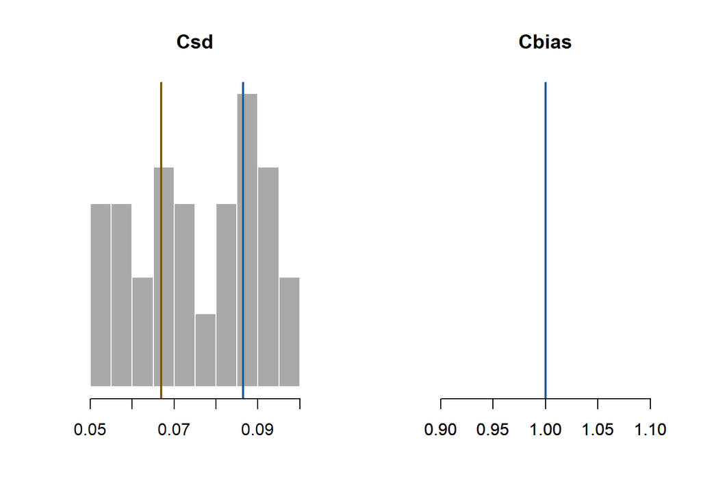

#### Time-Series

Time-series plots of catch observation error for historical and projection years:

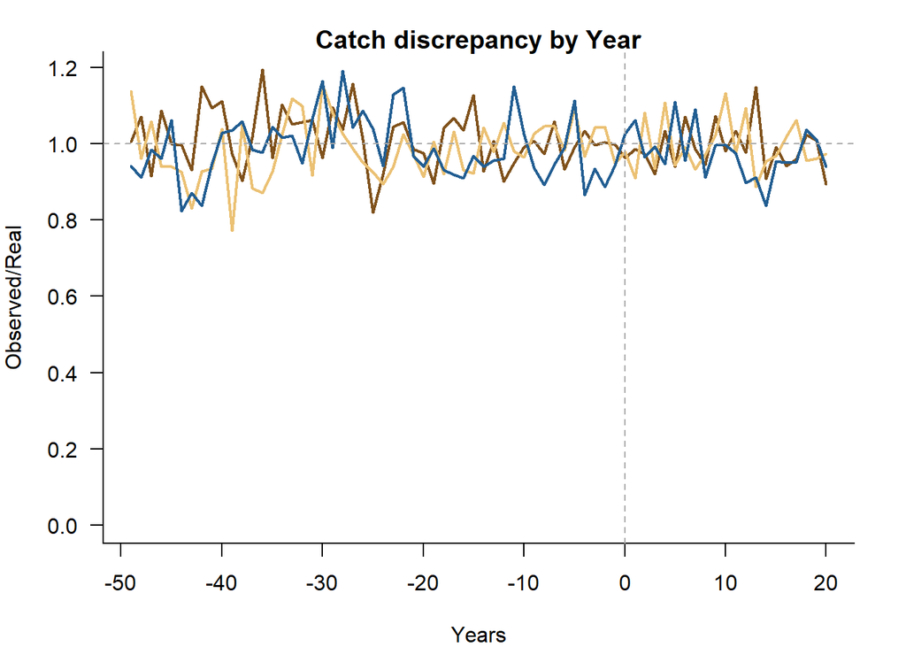

### Depletion Observations

#### Sampled Parameters

Histograms of 48 simulations of inter-annual variability in depletion observations (`Dobs`) and persistent bias in observed depletion (`Dbias`), with vertical colored lines indicating 3 randomly drawn values used in other plots:

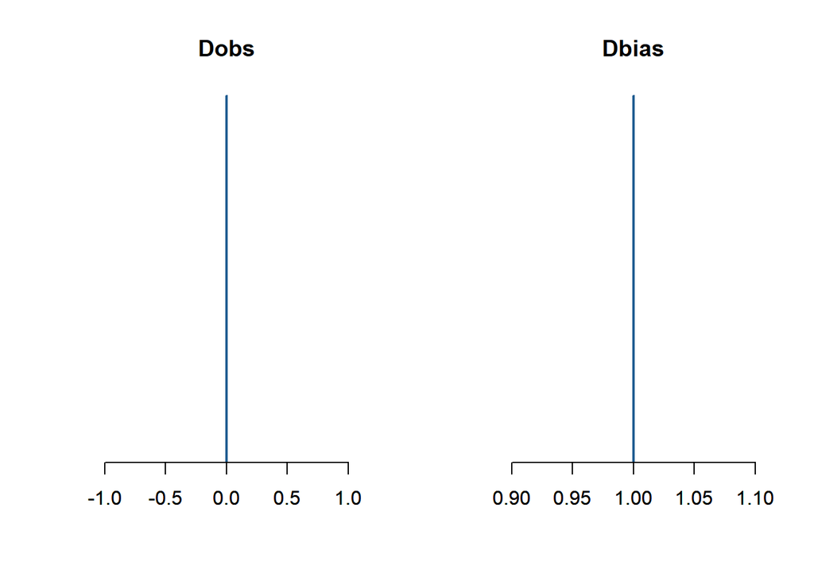

#### Time-Series

Time-series plots of depletion observation error for historical and projection years:

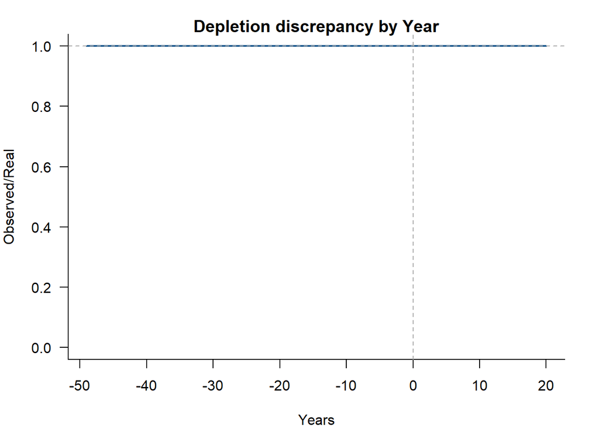

### Abundance Observations

#### Sampled Parameters

Histograms of 48 simulations of inter-annual variability in abundance observations (`Btobs`) and persistent bias in observed abundance (`Btbias`), with vertical colored lines indicating 3 randomly drawn values used in other plots:

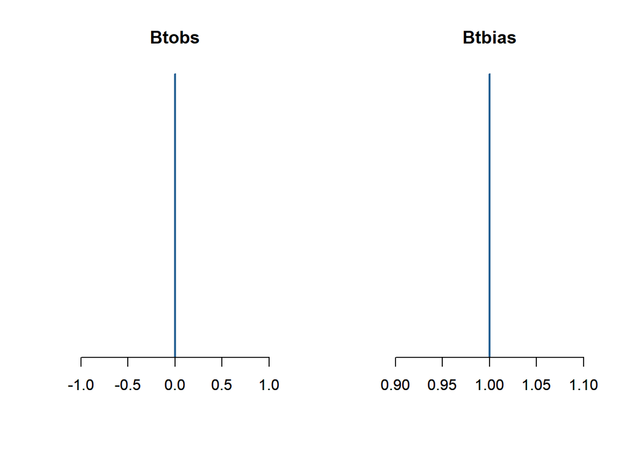

#### Time-Series

Time-series plots of abundance observation error for historical and projection years:

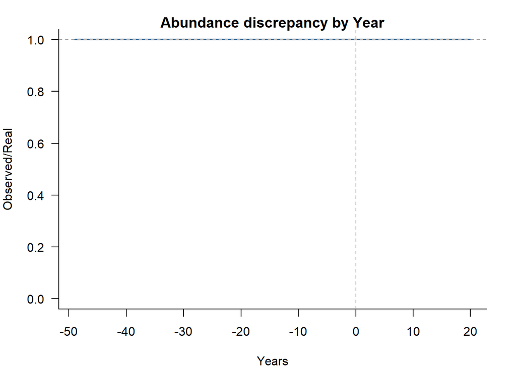

### Index Observations

#### Sampled Parameters

Histograms of 48 simulations of inter-annual variability in index observations (`Iobs`) and hyper-stability/depletion in observed index (`beta`), with vertical colored lines indicating 3 randomly drawn values used in other plots:

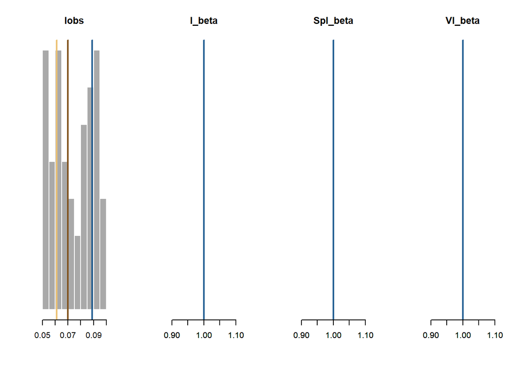

#### Time-Series

Time-series plot of 3 samples of index observation error:

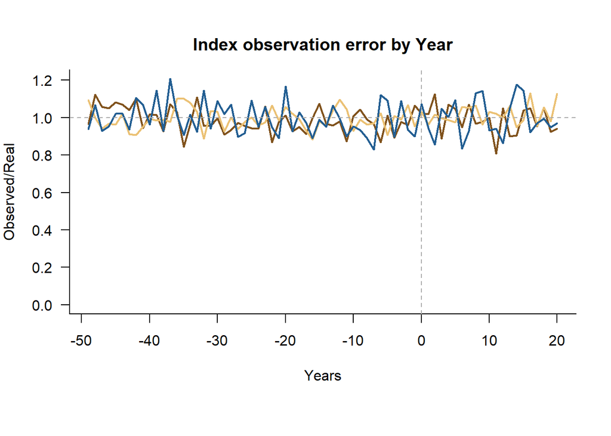

Plot showing an example true abundance index (blue) with 3 samples of index observation error and the hyper-stability/depletion parameter (`beta`):

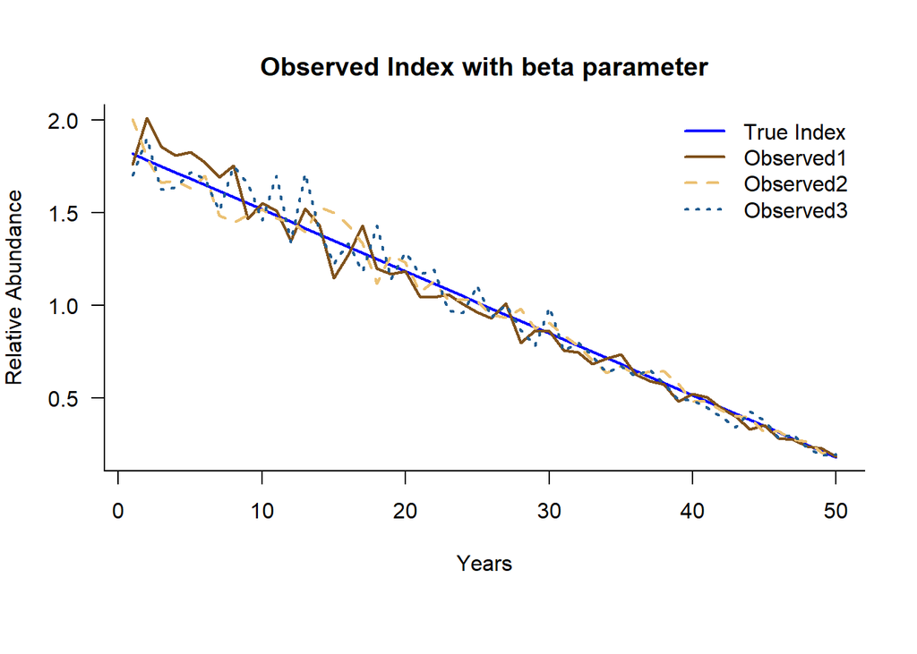

### Recruitment Observations

#### Sampled Parameters

Histograms of 48 simulations of inter-annual variability in index observations (`Recsd`) , with vertical colored lines indicating 3 randomly drawn values used in other plots:

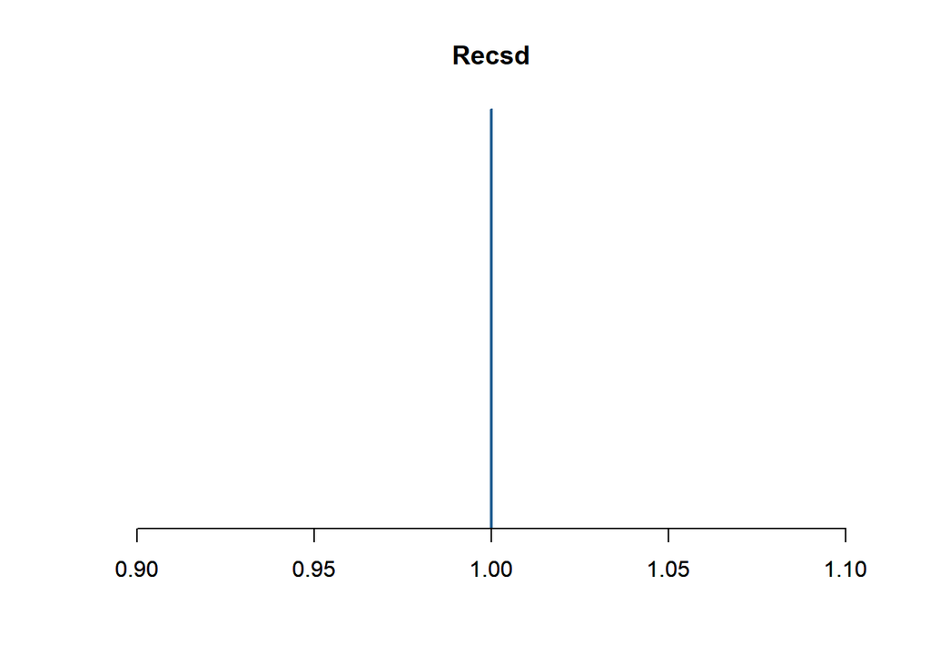

#### Time-Series

Timeseries plots of observeration error for recruitment:

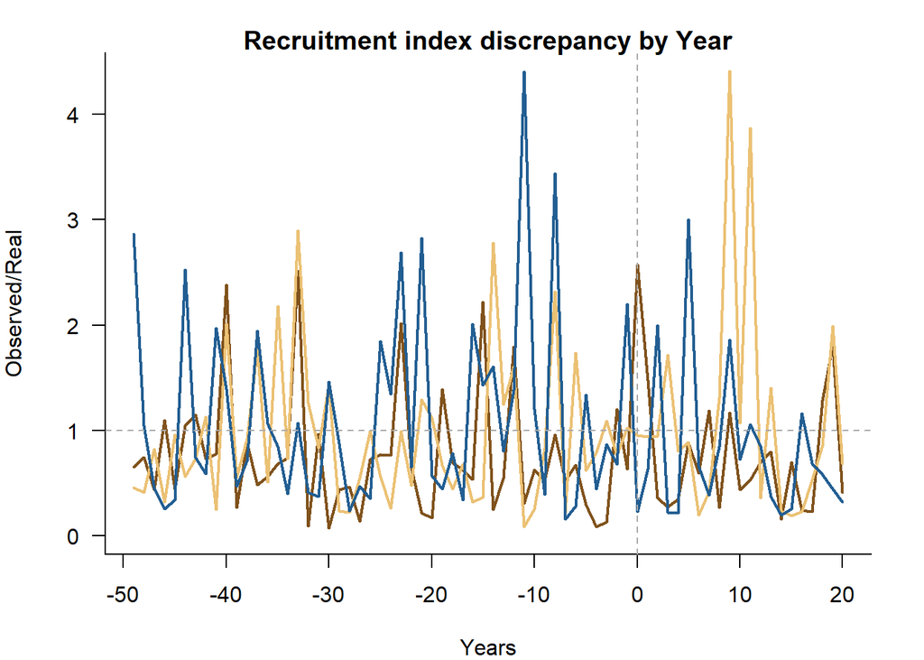

### Composition Observations

#### Sampled Parameters

Histograms of 48 simulations of catch-at-age effective sample size (`CAA_ESS`) and sample size (`CAA_nsamp`) and catch-at-length effective (`CAL_ESS`) and actual sample size (`CAL_nsamp`) with vertical colored lines indicating 3 randomly drawn values:

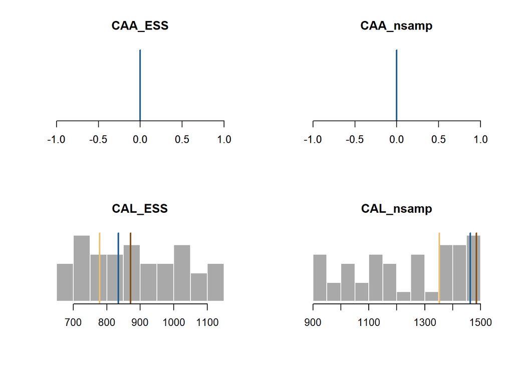